# **Capstone project: Providing data-driven suggestions for HR**

## Description and deliverables

This capstone project is an opportunity for you to analyze a dataset and build predictive models that can provide insights to the Human Resources (HR) department of a large consulting firm.

Upon completion, you will have two artifacts that you would be able to present to future employers. One is a brief one-page summary of this project that you would present to external stakeholders as the data professional in Salifort Motors. The other is a complete code notebook provided here. Please consider your prior course work and select one way to achieve this given project question. Either use a regression model or machine learning model to predict whether or not an employee will leave the company. The exemplar following this actiivty shows both approaches, but you only need to do one.

In your deliverables, you will include the model evaluation (and interpretation if applicable), a data visualization(s) of your choice that is directly related to the question you ask, ethical considerations, and the resources you used to troubleshoot and find answers or solutions.

# **PACE stages**

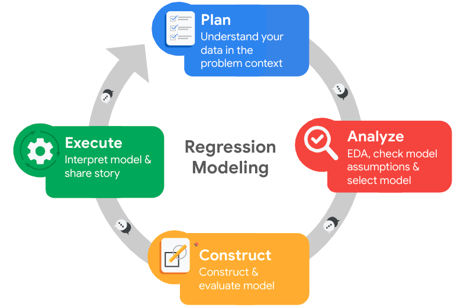

## **Pace: Plan**

Consider the questions in your PACE Strategy Document to reflect on the Plan stage.

In this stage, consider the following:

### Understand the business scenario and problem

The HR department at Salifort Motors wants to take some initiatives to improve employee satisfaction levels at the company. They collected data from employees, but now they don’t know what to do with it. They refer to you as a data analytics professional and ask you to provide data-driven suggestions based on your understanding of the data. They have the following question: what’s likely to make the employee leave the company?

Your goals in this project are to analyze the data collected by the HR department and to build a model that predicts whether or not an employee will leave the company.

If you can predict employees likely to quit, it might be possible to identify factors that contribute to their leaving. Because it is time-consuming and expensive to find, interview, and hire new employees, increasing employee retention will be beneficial to the company.

### Familiarize yourself with the HR dataset

The dataset that you'll be using in this lab contains 15,000 rows and 10 columns for the variables listed below.

**Note:** you don't need to download any data to complete this lab. For more information about the data, refer to its source on [Kaggle](https://www.kaggle.com/datasets/mfaisalqureshi/hr-analytics-and-job-prediction?select=HR_comma_sep.csv).

| Variable | Description |  |
| --- | --- | --- |
| satisfaction_level | Employee-reported job satisfaction level [0–1] |  |
| last_evaluation | Score of employee's last performance review [0–1] |  |
| number_project | Number of projects employee contributes to |  |
| average_monthly_hours | Average number of hours employee worked per month |  |
| time_spend_company | How long the employee has been with the company (years) |  |
| Work_accident | Whether or not the employee experienced an accident while at work |  |
| left | Whether or not the employee left the company |  |
| promotion_last_5years | Whether or not the employee was promoted in the last 5 years |  |
| Department | The employee's department |  |
| salary | The employee's salary (U.S. dollars) |  |

💭

### Reflect on these questions as you complete the plan stage.

- Who are your stakeholders for this project?
- What are you trying to solve or accomplish?
- What are your initial observations when you explore the data?
- What resources do you find yourself using as you complete this stage? (Make sure to include the links.)
- Do you have any ethical considerations in this stage?

```
Stakeholders:
```

The HR department for Salifort motors, a fictional alternative energy vehicle company

```
Task:
```

Fit an appropriate machine learning model in order to predict whether any employee is likely to leave the company

```
Initial observations:
```

Much of the data is categorical, lending itself well to a tree based prediction model. The numerical columns last_evaluation and satisfaction_level are already scaled, while the few remaining numerical columns should be scaled to fit a logistic regression model. There are also some outliers in the time_spend_company (tenure) column that would need to be addressed as part of preprocessing for a logistic regression model. Given this, it would make sense to go with a tree based model.

```
Resources referenced:
```

Google and the Google Advanced Data Analytics coursework

```
Ethical considerations:
```

The data is anonymized, which is important. Were there individual names for example, they should be dropped from the dataset so that it does not discriminate against employees with similar names. The business plan to address predictive features should be in service of an employee's wellbeing as well as the productivity of the business, so it is important that the data be interpreted correctly.

## Step 1. Imports

- Import packages
- Load dataset

### Import packages

```python
# Import packages
import pandas as pd
import numpy as np
import matplotlib.pyplot as plt
import seaborn as sns
sns.set_theme()

from sklearn import metrics
from sklearn.model_selection import train_test_split, GridSearchCV
from xgboost import XGBClassifier, plot_importance
```

### Load dataset

`Pandas` is used to read a dataset called **`HR_capstone_dataset.csv`.** As shown in this cell, the dataset has been automatically loaded in for you. You do not need to download the .csv file, or provide more code, in order to access the dataset and proceed with this lab. Please continue with this activity by completing the following instructions.

```python
# RUN THIS CELL TO IMPORT YOUR DATA.

# Load dataset into a dataframe
### YOUR CODE HERE ###
df0 = pd.read_csv("HR_capstone_dataset.csv")


# Display first few rows of the dataframe
df0.head()
```

|  | satisfaction_level | last_evaluation | number_project | average_montly_hours | time_spend_company | Work_accident | left | promotion_last_5years | Department | salary |
| --- | --- | --- | --- | --- | --- | --- | --- | --- | --- | --- |
| 0 | 0.38 | 0.53 | 2 | 157 | 3 | 0 | 1 | 0 | sales | low |
| 1 | 0.80 | 0.86 | 5 | 262 | 6 | 0 | 1 | 0 | sales | medium |
| 2 | 0.11 | 0.88 | 7 | 272 | 4 | 0 | 1 | 0 | sales | medium |
| 3 | 0.72 | 0.87 | 5 | 223 | 5 | 0 | 1 | 0 | sales | low |
| 4 | 0.37 | 0.52 | 2 | 159 | 3 | 0 | 1 | 0 | sales | low |

## Step 2. Data Exploration (Initial EDA and data cleaning)

- Understand your variables
- Clean your dataset (missing data, redundant data, outliers)

### Gather basic information about the data

```python
# Gather basic information about the data
df0.info()
```

```
<class 'pandas.core.frame.DataFrame'>
RangeIndex: 14999 entries, 0 to 14998
Data columns (total 10 columns):
 #   Column                 Non-Null Count  Dtype
---  ------                 --------------  -----
 0   satisfaction_level     14999 non-null  float64
 1   last_evaluation        14999 non-null  float64
 2   number_project         14999 non-null  int64
 3   average_montly_hours   14999 non-null  int64
 4   time_spend_company     14999 non-null  int64
 5   Work_accident          14999 non-null  int64
 6   left                   14999 non-null  int64
 7   promotion_last_5years  14999 non-null  int64
 8   Department             14999 non-null  object
 9   salary                 14999 non-null  object
dtypes: float64(2), int64(6), object(2)
memory usage: 1.1+ MB
```

### Gather descriptive statistics about the data

```python
# Gather descriptive statistics about the data
df0.describe()
```

|  | satisfaction_level | last_evaluation | number_project | average_montly_hours | time_spend_company | Work_accident | left | promotion_last_5years |
| --- | --- | --- | --- | --- | --- | --- | --- | --- |
| count | 14999.000000 | 14999.000000 | 14999.000000 | 14999.000000 | 14999.000000 | 14999.000000 | 14999.000000 | 14999.000000 |
| mean | 0.612834 | 0.716102 | 3.803054 | 201.050337 | 3.498233 | 0.144610 | 0.238083 | 0.021268 |
| std | 0.248631 | 0.171169 | 1.232592 | 49.943099 | 1.460136 | 0.351719 | 0.425924 | 0.144281 |
| min | 0.090000 | 0.360000 | 2.000000 | 96.000000 | 2.000000 | 0.000000 | 0.000000 | 0.000000 |
| 25% | 0.440000 | 0.560000 | 3.000000 | 156.000000 | 3.000000 | 0.000000 | 0.000000 | 0.000000 |
| 50% | 0.640000 | 0.720000 | 4.000000 | 200.000000 | 3.000000 | 0.000000 | 0.000000 | 0.000000 |
| 75% | 0.820000 | 0.870000 | 5.000000 | 245.000000 | 4.000000 | 0.000000 | 0.000000 | 0.000000 |
| max | 1.000000 | 1.000000 | 7.000000 | 310.000000 | 10.000000 | 1.000000 | 1.000000 | 1.000000 |

### Rename columns

As a data cleaning step, rename the columns as needed. Standardize the column names so that they are all in `snake_case`, correct any column names that are misspelled, and make column names more concise as needed.

```python
# Display all column names
df0.columns
```

```
Index(['satisfaction_level', 'last_evaluation', 'number_project',
       'average_montly_hours', 'time_spend_company', 'Work_accident', 'left',
       'promotion_last_5years', 'Department', 'salary'],
      dtype='object')
```

```python
# Rename columns as needed
df0.rename(
    {'satisfaction_level':'satisfaction',
     'number_project':'projects',
     'average_montly_hours':'hours',
     'time_spend_company':'tenure',
     'Work_accident':'accident',
     'promotion_last_5years':'promoted',
     'Department':'department'}, axis=1, inplace=True)

# Display all column names after the update
df0.columns
```

```
Index(['satisfaction', 'last_evaluation', 'projects', 'hours', 'tenure',
       'accident', 'left', 'promoted', 'department', 'salary'],
      dtype='object')
```

### Check missing values

Check for any missing values in the data.

```python
# Check for missing values
df0.isna().sum()
```

```
satisfaction       0
last_evaluation    0
projects           0
hours              0
tenure             0
accident           0
left               0
promoted           0
department         0
salary             0
dtype: int64
```

### Check duplicates

Check for any duplicate entries in the data.

```python
# Check for duplicates
df0[df0.duplicated()].count()
```

```
satisfaction       3008
last_evaluation    3008
projects           3008
hours              3008
tenure             3008
accident           3008
left               3008
promoted           3008
department         3008
salary             3008
dtype: int64
```

```python
# Inspect some rows containing duplicates as needed
df0[df0.duplicated(subset=['satisfaction'], keep=False)].sort_values(by='satisfaction').head(10)
```

|  | satisfaction | last_evaluation | projects | hours | tenure | accident | left | promoted | department | salary |
| --- | --- | --- | --- | --- | --- | --- | --- | --- | --- | --- |
| 14484 | 0.09 | 0.96 | 6 | 296 | 4 | 0 | 1 | 0 | technical | low |
| 1873 | 0.09 | 0.93 | 6 | 279 | 4 | 0 | 1 | 0 | technical | low |
| 340 | 0.09 | 0.89 | 7 | 308 | 5 | 0 | 1 | 0 | hr | medium |
| 1882 | 0.09 | 0.89 | 6 | 282 | 4 | 0 | 1 | 0 | support | low |
| 332 | 0.09 | 0.98 | 6 | 271 | 4 | 0 | 1 | 0 | sales | low |
| 12765 | 0.09 | 0.87 | 3 | 214 | 2 | 0 | 1 | 0 | support | medium |
| 12761 | 0.09 | 0.93 | 6 | 249 | 4 | 0 | 1 | 0 | sales | low |
| 350 | 0.09 | 0.80 | 6 | 304 | 5 | 0 | 1 | 0 | technical | medium |
| 761 | 0.09 | 0.93 | 6 | 249 | 4 | 0 | 1 | 0 | sales | low |
| 14489 | 0.09 | 0.78 | 6 | 254 | 4 | 0 | 1 | 0 | support | low |

```python
# Drop duplicates and save resulting dataframe in a new variable as needed
df_subset = df0.drop_duplicates()

# Display first few rows of new dataframe as needed
df_subset.head()
```

|  | satisfaction | last_evaluation | projects | hours | tenure | accident | left | promoted | department | salary |
| --- | --- | --- | --- | --- | --- | --- | --- | --- | --- | --- |
| 0 | 0.38 | 0.53 | 2 | 157 | 3 | 0 | 1 | 0 | sales | low |
| 1 | 0.80 | 0.86 | 5 | 262 | 6 | 0 | 1 | 0 | sales | medium |
| 2 | 0.11 | 0.88 | 7 | 272 | 4 | 0 | 1 | 0 | sales | medium |
| 3 | 0.72 | 0.87 | 5 | 223 | 5 | 0 | 1 | 0 | sales | low |
| 4 | 0.37 | 0.52 | 2 | 159 | 3 | 0 | 1 | 0 | sales | low |

### Check outliers

Check for outliers in the data.

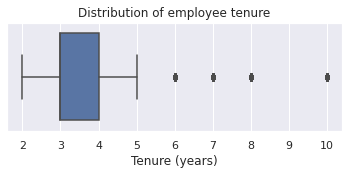

```python
# Create a boxplot to visualize distribution of `tenure` and detect any outliers
plt.figure(figsize=(6,2))
sns.boxplot(df_subset['tenure'])
plt.title('Distribution of employee tenure')
plt.xlabel('Tenure (years)')
plt.show()
```

```python
# Determine the number of rows containing outliers
outliers = df_subset[df_subset['tenure'] > 5]['tenure'].count()
print('Number of employees with more than 5 years of tenure:', outliers)
```

```
Number of employees with more than 5 years of tenure: 824
```

Certain types of models are more sensitive to outliers than others. When you get to the stage of building your model, consider whether to remove outliers, based on the type of model you decide to use.

# pAce: Analyze Stage

- Perform EDA (analyze relationships between variables)

💭

### Reflect on these questions as you complete the analyze stage.

- What did you observe about the relationships between variables?
- What do you observe about the distributions in the data?
- What transformations did you make with your data? Why did you chose to make those decisions?
- What are some purposes of EDA before constructing a predictive model?
- What resources do you find yourself using as you complete this stage? (Make sure to include the links.)
- Do you have any ethical considerations in this stage?

Variable Relationships:

- Tenure vs. Left: 3-6 years of tenure have most occurences of left
- Satisfaction vs. Left: Median is ~ 0.4 for left, and 0.6 for stayed.
- Avg. Satisfaction vs. Tenure: dip 4-6 years, consistent otherwise
- Last Eval vs. Left: 0.6-0.8 range has lowest occurences of left
- Hours vs. Left: 160-220 range has lowest occurences of left
- Accident vs. employment status: much higher proportion of Stayed had an accident (~3 times that of left)
- Promotion vs. employment status: much higher proportion of Stayed had promotion (~5 times that of left)
- Salary vs. employment status: Nearly all High salary employees Stayed (~8% total employees)
- Department vs. employment status: Mostly uniformly distributed proportion of Left. R&D and Management have relatively fewer employees who Left, while HR has slightly more.

Distributions:

Most columns in the dataset were renamed in order to keep them consistent and easier to use. A new column was made for the purpose of more easily plotting titled "employment_status", which represents the boolean values in the "left" column with strings. The categorical columns Salary and Department will need to be encoded in order for a model to interpret them.

Purpose of EDA:

This analysis will help to inform the development of a model to predict whether an employee will leave the company in a few ways. First, by examining the distribution of the different variables, it is made clear whether there are outliers to contend with, and sets expectations for potentially strong predictor variables. EDA also informs us on the types and scale of different variables, which are essential to understand before choosing a model. Model assumptions can also be validated by examining multicollinearity between predictor variables in the case of logistic regression, for example. Structuring and cleaning the data to perform feature engineering begins with the EDA process as well.

Resources:

Google and the Advanced Data Analytics Certificate coursework

Ethical considerations:

Ethical considerations at this stage are largely with respect to the proper interpretation of the data, and ensuring that details are not missed during transformation and analysis that could negatively impact a model down the line. If the proper assumptions are not checked, for example, a model would not perform well on the data. If this goes unnoticed, it could lead to the team making misinformed decisions and wasting valuable resources.

## Step 2. Data Exploration (Continue EDA)

Begin by understanding how many employees left and what percentage of all employees this figure represents.

```python
# Get numbers of people who left vs. stayed
num_left = df_subset['left'].value_counts()
print(num_left[0], 'employees stayed, and', num_left[1],'left.')
# Get percentages of people who left vs. stayed
percent_left = (df_subset['left'].value_counts(normalize=True)*100).round(2)
print(percent_left[0], 'percent of employees stayed, and', percent_left[1],'percent of employees left.')
```

```
10000 employees stayed, and 1991 left.
83.4 percent of employees stayed, and 16.6 percent of employees left.
```

### Data visualizations

Now, examine variables that you're interested in, and create plots to visualize relationships between variables in the data.

```python
# Add a column that represents 'left' with strings for ease of plotting

df_subset['employment_status'] = df_subset['left'].replace({0:'Stayed',1:'Left'})
```

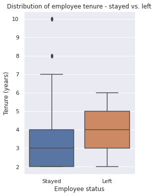

```python
plt.figure(figsize=(4,6))
sns.boxplot(data=df_subset,
            x='left',
            y='tenure',
           )
plt.title('Distribution of employee tenure - stayed vs. left')
plt.xlabel('Employee status')
plt.xticks(ticks=[0,1], labels=['Stayed','Left'])
plt.ylabel('Tenure (years)')
plt.show()
```

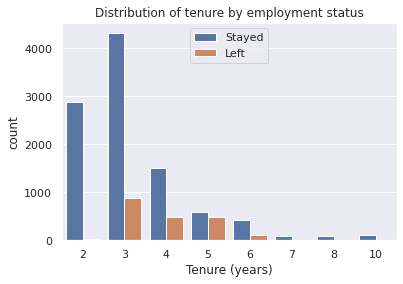

```python
sns.countplot(data=df_subset,
              x='tenure',
              hue='employment_status',
              hue_order=['Stayed', 'Left'],
             )
plt.title('Distribution of tenure by employment status')
plt.xlabel('Tenure (years)')
plt.legend()
plt.show()
```

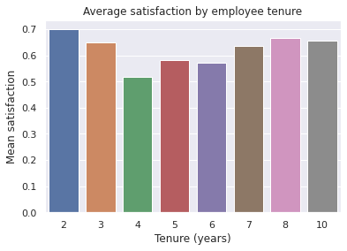

```python
# Create a plot as needed
sns.barplot(data=df_subset,
            x='tenure',
            y='satisfaction',
            ci=None,
           )
plt.title('Average satisfaction by employee tenure')
plt.xlabel('Tenure (years)')
plt.ylabel('Mean satisfaction')
plt.show()
```

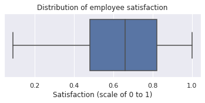

```python
plt.figure(figsize=(6,2))
sns.boxplot(df_subset['satisfaction'])
plt.title('Distribution of employee satisfaction')
plt.xlabel('Satisfaction (scale of 0 to 1)')
plt.show()
```

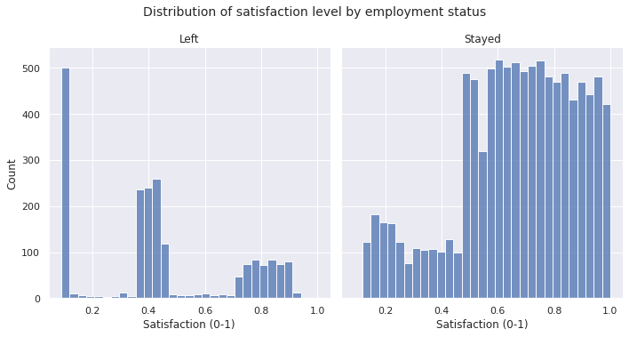

```python
g = sns.displot(data=df_subset,
            x='satisfaction',
            col='employment_status'
           )
for i, ax in enumerate(g.axes[0]):
    ax.set_title(["Left", "Stayed"][i])
for i, ax in enumerate(g.axes[-1]):
    ax.set_xlabel("Satisfaction (0-1)")
plt.gcf().suptitle("Distribution of satisfaction level by employment status", y=1.05, fontsize=14)
plt.show()
```

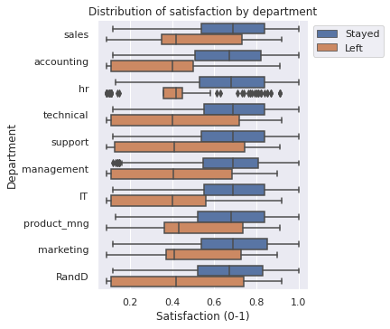

```python
sns.catplot(data=df_subset,
            x='satisfaction',
            y='department',
            hue='employment_status',
            hue_order=['Stayed','Left'],
            kind='box',
            legend_out=False,
           )

plt.title('Distribution of satisfaction by department')
plt.xlabel('Satisfaction (0-1)')
plt.ylabel('Department')
plt.legend(title="", bbox_to_anchor=(1,1))
plt.show()
```

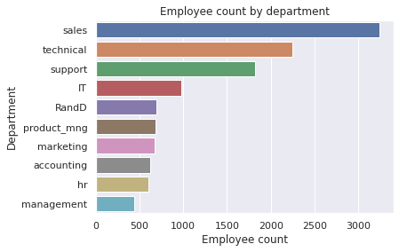

```python
plt.figure(figsize=(6,4))
sns.countplot(y=df_subset['department'],
              order=df_subset['department'].value_counts().index,
             )
plt.title('Employee count by department')
plt.ylabel('Department')
plt.xlabel('Employee count')
plt.show()
```

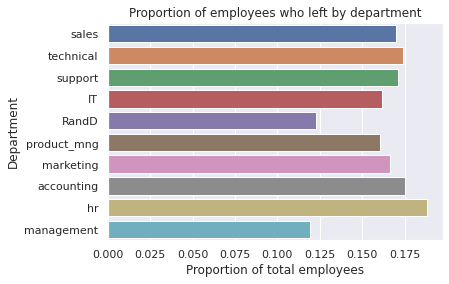

```python
plt.figure(figsize=(6,4))
sns.barplot(data=df_subset,
            y='department',
            x='left',
            order=df_subset['department'].value_counts().index,
            ci=False
           )
plt.title('Proportion of employees who left by department')
plt.ylabel('Department')
plt.xlabel('Proportion of total employees')
plt.show()
```

[figure not shown]

```python
plt.figure(figsize=(6,2))
sns.boxplot(data=df_subset,
            x='projects',
            y='employment_status'
           )
plt.title('Distribution of project contribution count per employee')
plt.xlabel('Project count')
plt.yticks(ticks=[0,1], labels=['Stayed','Left'])
plt.ylabel('Employment status')
plt.show()
```

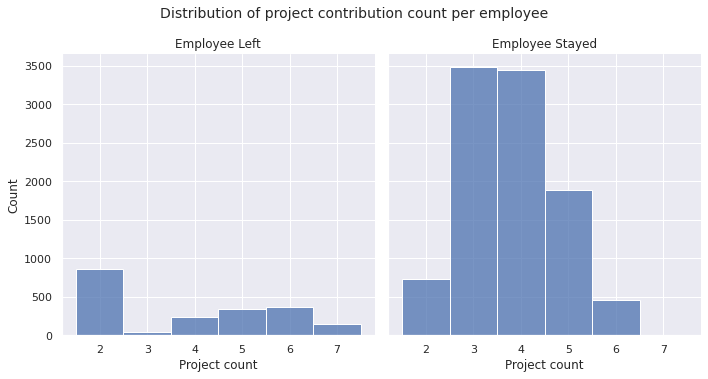

```python
g = sns.displot(data=df_subset,
            x='projects',
            col='employment_status',
            discrete=True,
           )
for i, ax in enumerate(g.axes[0]):
    ax.set_title(["Employee Left", "Employee Stayed"][i])
for i, ax in enumerate(g.axes[-1]):
    ax.set_xlabel("Project count")
plt.gcf().suptitle("Distribution of project contribution count per employee", y=1.05, fontsize=14)
plt.show()
```

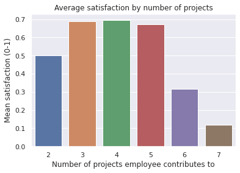

```python
# Create a plot as needed
sns.barplot(data=df_subset,
            x='projects',
            y='satisfaction',
            ci=None,
           )
plt.title('Average satisfaction by number of projects')
plt.xlabel('Number of projects employee contributes to')
plt.ylabel('Mean satisfaction (0-1)')
plt.show()
```

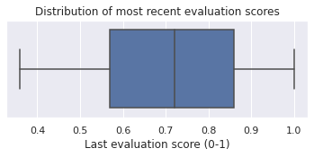

```python
plt.figure(figsize=(6,2))
sns.boxplot(df_subset['last_evaluation'])
plt.title('Distribution of most recent evaluation scores')
plt.xlabel('Last evaluation score (0-1)')
plt.show()
```

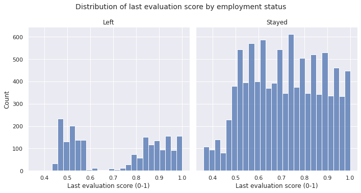

```python
g = sns.displot(data=df_subset,
            x='last_evaluation',
            col='employment_status'
           )
for i, ax in enumerate(g.axes[0]):
    ax.set_title(["Left", "Stayed"][i])
for i, ax in enumerate(g.axes[-1]):
    ax.set_xlabel("Last evaluation score (0-1)")
plt.gcf().suptitle("Distribution of last evaluation score by employment status", y=1.05, fontsize=14)
plt.show()
```

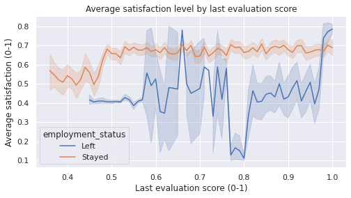

```python
plt.figure(figsize=(8,4))
sns.lineplot(data=df_subset,
             x='last_evaluation',
             y='satisfaction',
             hue='employment_status'
            )
plt.title('Average satisfaction level by last evaluation score')
plt.xlabel('Last evaluation score (0-1)')
plt.ylabel('Average satisfaction (0-1)')
plt.show()
```

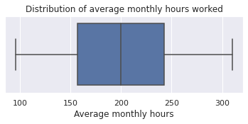

```python
plt.figure(figsize=(6,2))
sns.boxplot(df_subset['hours'])
plt.title('Distribution of average monthly hours worked')
plt.xlabel('Average monthly hours')
plt.show()
```

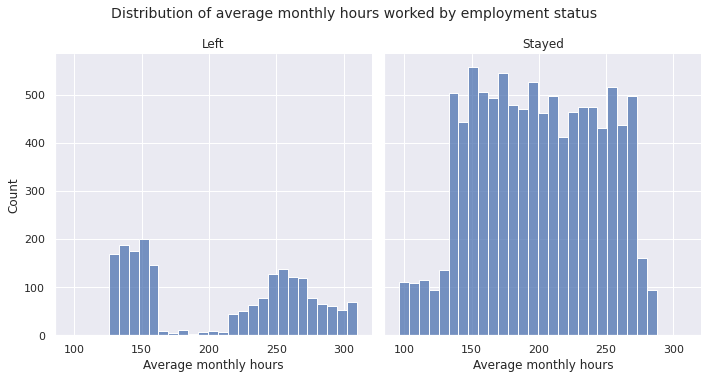

```python
g = sns.displot(data=df_subset,
            x='hours',
            col='employment_status'
           )
for i, ax in enumerate(g.axes[0]):
    ax.set_title(["Left", "Stayed"][i])
for i, ax in enumerate(g.axes[-1]):
    ax.set_xlabel("Average monthly hours")
plt.gcf().suptitle("Distribution of average monthly hours worked by employment status", y=1.05, fontsize=14)
plt.show()
```

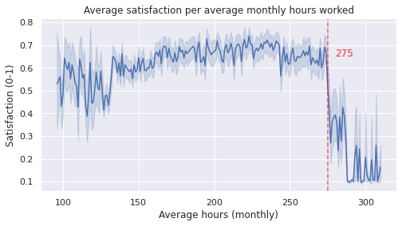

```python
plt.figure(figsize=(8,4))
sns.lineplot(data=df_subset,
            x='hours',
            y='satisfaction',
            )
plt.title('Average satisfaction per average monthly hours worked')
plt.xlabel('Average hours (monthly)')
plt.ylabel('Satisfaction (0-1)')
plt.axvline(x=275, color='red', alpha=0.6, ls='--')
plt.text(280,0.65,'275', color='red', alpha=0.8)
plt.show()
```

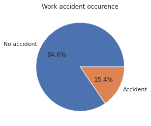

```python
df_subset['accident'].value_counts().plot.pie(
    labels=['No accident','Accident'], autopct="%1.1f%%",)
plt.title('Work accident occurence')
plt.ylabel('')
plt.show()
```

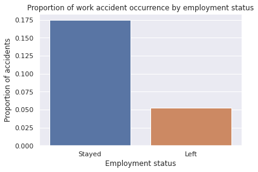

```python
sns.barplot(data=df_subset,
             x='employment_status',
             y='accident',
            ci=False,
            order=['Stayed', 'Left']
           )
plt.title('Proportion of work accident occurrence by employment status')
plt.xlabel('Employment status')
plt.ylabel('Proportion of accidents')
plt.show()
```

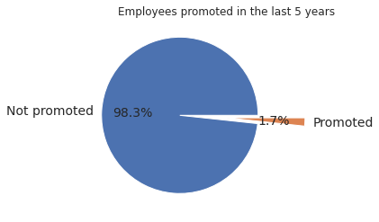

```python
df_subset['promoted'].value_counts().plot.pie(
    labels=['Not promoted','Promoted'], autopct="%1.1f%%",
    explode=[0.6, 0], textprops={"fontsize":14})
plt.title('Employees promoted in the last 5 years')
plt.ylabel('')
plt.show()
```

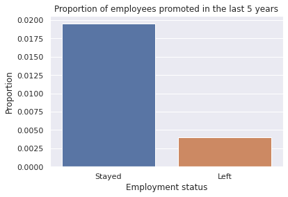

```python
sns.barplot(data=df_subset,
             x='employment_status',
             y='promoted',
            ci=False,
            order=['Stayed', 'Left']
           )
plt.title('Proportion of employees promoted in the last 5 years')
plt.xlabel('Employment status')
plt.ylabel('Proportion')
plt.show()
```

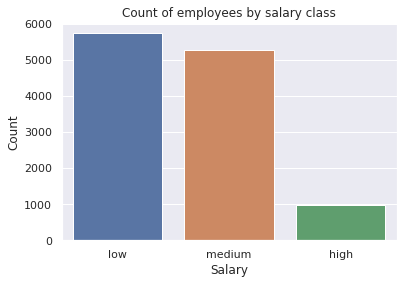

```python
sns.countplot(x=df_subset['salary'])
plt.title('Count of employees by salary class')
plt.xlabel('Salary')
plt.ylabel('Count')
plt.show()
```

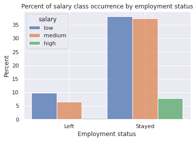

```python
sns.histplot(data=df_subset,
             binwidth=1,
             x='employment_status',
             hue='salary',
             stat="percent",
             multiple="dodge",
            )
plt.title('Percent of salary class occurrence by employment status')
plt.xlabel('Employment status')
plt.show()
```

# paCe: Construct Stage

- Determine which models are most appropriate
- Construct the model
- Confirm model assumptions
- Evaluate model results to determine how well your model fits the data

💭

### Reflect on these questions as you complete the constructing stage.

- Do you notice anything odd?
- Which independent variables did you choose for the model and why?
- Are each of the assumptions met?
- How well does your model fit the data?
- Can you improve it? Is there anything you would change about the model?
- What resources do you find yourself using as you complete this stage? (Make sure to include the links.)
- Do you have any ethical considerations in this stage?

Anything Odd?

The XGBoost model fits the data very well, with all evaluation scores being very high. When tuning the hyperparameters using GridSearchCV, the recall score was prioritized with the "refit" argument. This is to ensure that the model captures as many true positives as possible, even at the expense of precision and accuracy. Despite this, the precision and accuracy scores (and consequently the F1 score) remain high in the final model. It may be the case that the model is overfit. This would become evident as it predicts whether an employee has left on new data.

Independent Variables:

I chose to use all available training features, which required encoding salary and department. This is because an XGBoost model can interpret this unscaled data properly, and does have require that features display no multicollinearity.

Assumptions:

The primary assumption of the XGBoost model in this case is that the data accurately reflects employee behavior.

Model Fit:

- Accuracy score: 0.985
- Precision score: 0.985
- Recall score: 0.924
- F1 score: 0.953

Improvements:

Feature engineering, the introduction of more data, and comparing the model against other types of models could lead to improvements in model performance.

Resources:

Google Advanced Data Analytics: Course 6 Project Lab

Ethical Considerations:

Since this model was trained and validated on all of the available data, it is essential to compare its performance with incoming data. If the model fit changes drastically, it will need to be retuned and reinterpreted so that the team does not act on poor insights.

## Step 3. Model Building, Step 4. Results and Evaluation

- Fit a model that predicts the outcome variable using two or more independent variables
- Check model assumptions
- Evaluate the model

### Identify the type of prediction task.

The prediction task at hand is a classification one, where we will fit a model to predict whether the class of the "left" variable is 0 (Stayed) or 1 (Left).

### Identify the types of models most appropriate for this task.

Logistic regression, Naive Bayes, Decision Tree, Decision Tree based ensemble models such as Random Forest, or boosting models such as XGBoost are all appropriate for this task.

### Modeling

Add as many cells as you need to conduct the modeling process.

```python
# Encode categorical variables
df_dummies = pd.get_dummies(df_subset, columns = ['salary', 'department'])
```

```python
# Subset the data into X (predictor) and y (target)
X = df_dummies.drop(columns=['employment_status','left'])
y = df_dummies['left']
```

```python
# Split the data into training and testing set
X_train, X_test, y_train, y_test = train_test_split(X, y, test_size=0.25, stratify=y, random_state=42)
```

```python
# Define classifier model
xgb = XGBClassifier(objective='binary:logistic', random_state=42)

# Define parameters for hyperparameter tuning
cv_params = cv_params = {'max_depth': [4, 6, 8],
              'min_child_weight': [3, 5, 7],
              'learning_rate': [0.1, 0.2, 0.3],
              'n_estimators': [10, 15, 20],
              'subsample': [1],
              'colsample_bytree': [0.7]
              }

# Define scoring criteria
scoring = {'accuracy', 'precision', 'recall', 'f1'}

# Construct GridSearch
xgb_cv = GridSearchCV(xgb,
                      cv_params,
                      scoring = scoring,
                      cv = 5,
                      refit = 'recall'
                     )
```

```python
%%time
# Fit the GridSearch model to training data
xgb_cv = xgb_cv.fit(X_train, y_train)
xgb_cv
```

```
CPU times: user 1min 17s, sys: 593 ms, total: 1min 17s
Wall time: 40.3 s
```

```
GridSearchCV(cv=5, error_score=nan,
             estimator=XGBClassifier(base_score=None, booster=None,
                                     callbacks=None, colsample_bylevel=None,
                                     colsample_bynode=None,
                                     colsample_bytree=None,
                                     early_stopping_rounds=None,
                                     enable_categorical=False, eval_metric=None,
                                     gamma=None, gpu_id=None, grow_policy=None,
                                     importance_type=None,
                                     interaction_constraints=None,
                                     learning_rate=None, max...
                                     predictor=None, random_state=42,
                                     reg_alpha=None, ...),
             iid='deprecated', n_jobs=None,
             param_grid={'colsample_bytree': [0.7],
                         'learning_rate': [0.1, 0.2, 0.3],
                         'max_depth': [4, 6, 8], 'min_child_weight': [3, 5, 7],
                         'n_estimators': [10, 15, 20], 'subsample': [1]},
             pre_dispatch='2*n_jobs', refit='recall', return_train_score=False,
             scoring={'f1', 'precision', 'accuracy', 'recall'}, verbose=0)
```

```python
# Print model best parameters
xgb_cv.best_params_
```

```
{'colsample_bytree': 0.7,
 'learning_rate': 0.3,
 'max_depth': 8,
 'min_child_weight': 3,
 'n_estimators': 20,
 'subsample': 1}
```

```python
# Make predictions on test data
y_pred = xgb_cv.best_estimator_.predict(X_test)
```

```python
# Print metrics
ac_score = metrics.accuracy_score(y_test, y_pred)
print('accuracy score:', ac_score)

pr_score = metrics.precision_score(y_test, y_pred)
print('precision score:', pr_score)

re_score = metrics.recall_score(y_test, y_pred)
print('recall score:', re_score)

f1_score = metrics.f1_score(y_test, y_pred)
print('f1 score:', f1_score)
```

```
accuracy score: 0.9849899933288859
precision score: 0.9850107066381156
recall score: 0.9236947791164659
f1 score: 0.9533678756476685
```

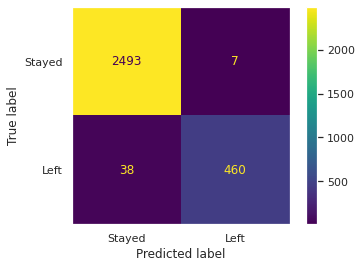

```python
# Create confusion matrix

cm = metrics.confusion_matrix(y_test, y_pred, labels=xgb_cv.classes_)
disp = metrics.ConfusionMatrixDisplay(confusion_matrix=cm, display_labels=['Stayed', 'Left'])
disp = disp.plot(values_format='')
plt.grid(None)
plt.show()
```

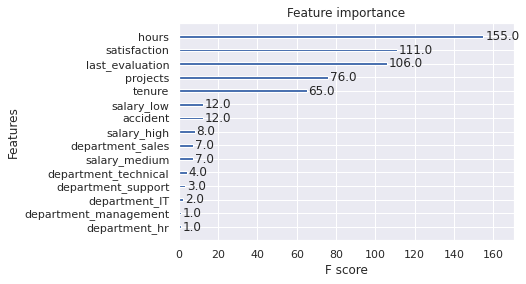

```python
# Plot feature importance

plot_importance(xgb_cv.best_estimator_);
```

# pacE: Execute Stage

- Interpret model performance and results
- Share actionable steps with stakeholders

💭

### Reflect on these questions as you complete the executing stage.

- What key insights emerged from your model(s)?
- What business recommendations do you propose based on the models built?
- What potential recommendations would you make to your manager/company?
- Do you think your model could be improved? Why or why not? How?
- Given what you know about the data and the models you were using, what other questions could you address for the team?
- What resources do you find yourself using as you complete this stage? (Make sure to include the links.)
- Do you have any ethical considerations in this stage?

Business Recommendations:

- Considering that the number of hours an employee works on average and the number of projects an employee contributes to are strong predictors for this model, initiatives to align employees' workload with those who are less likely to leave would likely be effective in improving retention. Of those who left, most employees worked outside the range of 165-220 hours per month on average. Those who left rarely contributed to just 3 projects, while a 3-5 project workload is most common for employees who stayed.
- Focusing retention efforts on employees who are approaching 3 years with the company would be prudent, given that most employees who left had a tenure of 3 to 6 years.

Management Recommendations:

- Employees whose last evaluation score fall in the range 0.6-0.75 tend not to leave the company. Job satisfaction varies much more greatly for employees with evaluation scores in that range who left the company. As last evaluation score approaches 0.8, employees who left tended to have very low satisfaction levels. It could be worth exploring the reasons that those with relatively high evaluation scores are dissatisfied. For example, were these employees previously scoring higher than 0.8 before falling below the threshold that would allow them a raise? We could also explore the ways in which we support those with poor evaluation scores, as they tend to be dissatisfied and leave more frequently.

Model Improvement:

- The current model performs excellently at predicting whether an employee will leave the company, but will need to be tested with new data and re-evaluated to ensure that the perfomance continues to be strong. Further feature engineering, the addition of more granular data (perhaps the last 3 evaluation scores for an employee, for example), and further hyperparameter tuning could all improve performance down the line.

Questions for the Team:

- Could we get further data into why employees left the company from exit interviews?
- Is there more historical data on previous evaluation scores that could be accessed?
- How is employee workload (number of projects contributed to, average monthly hours worked) determined?

Resources:

- scikit learn documentation Ethical Considerations:
- It is important to consider the actions taken when an employee is determined to be likely to leave. We should focus on supporting staff to improve their experience, and should not be punitive to those who are satisfied with more projects despite that being different from the norm, for example. Individuals should be treated with respect and the recognition that they have unique needs and preferences.

## Step 4. Results and Evaluation

- Interpret model
- Evaluate model performance using metrics
- Prepare results, visualizations, and actionable steps to share with stakeholders

### Summary of model results

In order to train this model, the data was randomly split between training data (75% of the total dataset) and testing data (25% of the total dataset). The data was stratified in order to maintain the same proportional representation of employees who left and employees who stayed within the split datasets, despite being randomly selected.

The model was evaluated using the following metrics:

- Precision: 0.985
- Accuracy: 0.985
- Recall: 0.924
- F1 Score: 0.953

These scores are all high, representing an excellent overall fit to the data. In this case, the recall score was prioritized when tuning the hyperparameters for the model. The final recall score of 0.924 tells us that the model correctly identified 92.4% of all employees in the test data who left the company.

### Conclusion, Recommendations, Next Steps

Recommendations:

- Focus retention efforts on employees who are approaching 3 years with the company, given that most employees who left had a tenure of 3 to 6 years, with newer employees in that range tending to leave more frequently.
- Establish an initiative to align employees' workload with those who are less likely to leave, where appropriate.
  - Of those who left, most employees worked outside the range of 165-220 hours per month on average.
  - Those who left rarely contributed to just 3 projects, while a 3-5 project workload is most common for employees who stayed.
- Explore why some employees are dissatisfied despite their performance review scores falling on the high range for those who leave. For example, were these employees previously scoring higher than 0.8 before falling below the threshold that would allow them a raise?
- Explore the ways in which we support those with poor performance review scores, as they tend to be dissatisfied and leave more frequently.

Next Steps:

- Continue to validate the model by testing it on new data and evaluating its performance.
- Improve the model by gathering more data - considering the following questions:
  - Could we get further data into why employees left the company from exit interviews?
  - Is there more historical data on previous evaluation scores that could be accessed?
  - How is employee workload (number of projects contributed to, average monthly hours worked) determined?

**Congratulations!** You've completed this lab. However, you may not notice a green check mark next to this item on Coursera's platform. Please continue your progress regardless of the check mark. Just click on the "save" icon at the top of this notebook to ensure your work has been logged.